# Trees

### More general error indexes

There are different indexes of misclassification error we can use instead of the deviance of the binomial distribution. This is handy when we are trying to compare response variables with more than 2 possible states. In order to use these other metrics, we must first rewrite the above equation once more, this time incorporating a function of *entropy,* $Q(\hat p_j)$.

$$ D = 2n \sum _{j=1}^J \frac{n_j}{n} Q(\hat p_j) $$

$Q(p_j)$ using the above method can be written generally as:

$$ Q(p_j) = \sum _{k \in K} p_{jk} log(p_{jk}) $$

Another misclassification index we can use for $Q(p)$ instead is called the Gini-index, and is written:

$$ Q(p_j) = \sum _{k \in K} p_{jk} (1-p_{jk}) $$

Here, instead of multiplying by a log, we instead multiply by the inverse probabilities for each state space, for each region.

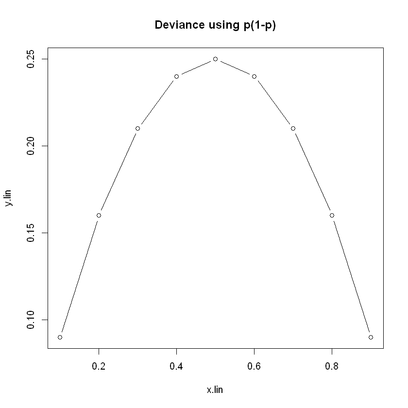

```r
x.lin <- seq(1:9)*.1
y.lin <- x.lin*(1-x.lin)

plot(x.lin, y.lin, main='Deviance using p(1-p)',type='b')
```

As we can see, this gives the same relative distribution of deviance as using our binary entropy indicator above.

## R code

Let's now big a classification tree model using R. We will use an on-line data set about juices. Each observation contains a response variable for choice, which has value either 'CH' or 'MM'.

We start by reading in our data:

```r
juice <- read.table("http://azzalini.stat.unipd.it/Book-DM/juice.data", header = TRUE)
juice[ , "store"] <- factor(juice[ , "store"])
v <- c(1, 3, 6:9, 13, 21)
juice <- juice[ , v]
head(juice)
```

A data.frame: 6 × 8

|  | choice <fct> | week <int> | priceCH <dbl> | priceMM <dbl> | discountCH <dbl> | discountMM <dbl> | loyaltyMM <dbl> | store <fct> |
| --- | --- | --- | --- | --- | --- | --- | --- | --- |
| 1 | CH | 237 | 1.75 | 1.99 | 0.00 | 0.0 | 0.500000 | 1 |
| 2 | CH | 239 | 1.75 | 1.99 | 0.00 | 0.3 | 0.400000 | 1 |
| 3 | CH | 245 | 1.86 | 2.09 | 0.17 | 0.0 | 0.320000 | 1 |
| 4 | MM | 227 | 1.69 | 1.69 | 0.00 | 0.0 | 0.600000 | 1 |
| 5 | CH | 228 | 1.69 | 1.69 | 0.00 | 0.0 | 0.043465 | 0 |
| 6 | CH | 230 | 1.69 | 1.99 | 0.00 | 0.0 | 0.034772 | 0 |

Our next step will be to split our data into a training and a test set, for testing our model.

```r
#--select training and test
set.seed(123)
n <- nrow(juice)
n1 <- round(n * 0.75)
n2 <- n - n1
permutation <- sample(1:n,n)
training <- sort(permutation[1:n1])
juice1 <- juice[training, ]
juice2 <- juice[-training, ]
```

We can now fit our model, again making use of the `tree` library.

```r
set.seed(123)
part1 <- sort(sample(training, 600))
part2 <- setdiff(training, part1)
f1 <- as.formula(paste("choice ~ ", paste(names(juice1)[-1], collapse = "+"),
                        collapse = NULL))
t1<- tree(f1, data = juice[part1, ], control = tree.control(nobs = length(part1),
                                                            minsize = 2, mindev = 0))
```

`t1` now represents our extremely over-fit tree, just like in regression trees. Don't really understand what the first two parts are here.

We can now try pruning our tree, to see which complexity gives the lowest deviance.

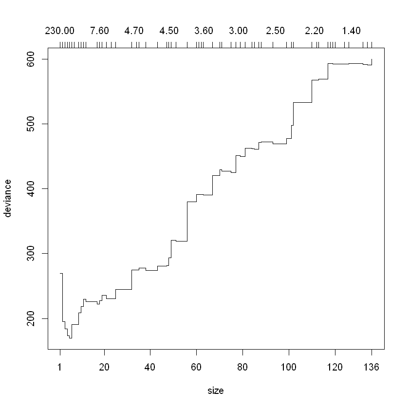

```r
t2<- prune.tree(t1, newdata = juice[part2, ])
# figure 5.20a
plot(t2)
```

As you can see, our model has quite a lot of steps. Let's find an automatic way of finding the J giving the lowest complexity.

5

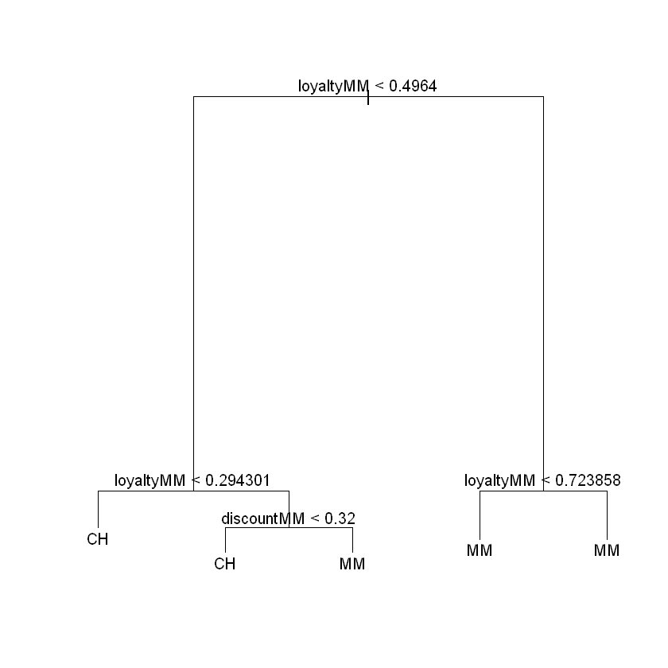

```r
J <- t2$size[t2$dev == min(t2$dev)]
J

t3 <- prune.tree(t1, best = J)
# figure 5.20b
plot(t3)
text(t3)
```

```
         observed
predicted  CH  MM
       CH 122  17
       MM  42  87
total error:  0.2201493
false positives/negatives:  0.2560976 0.1634615
```

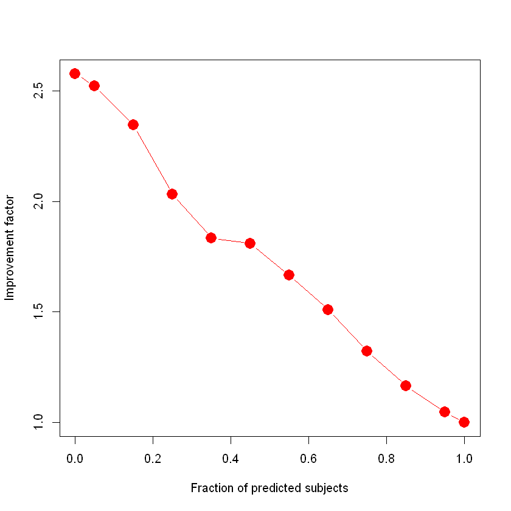

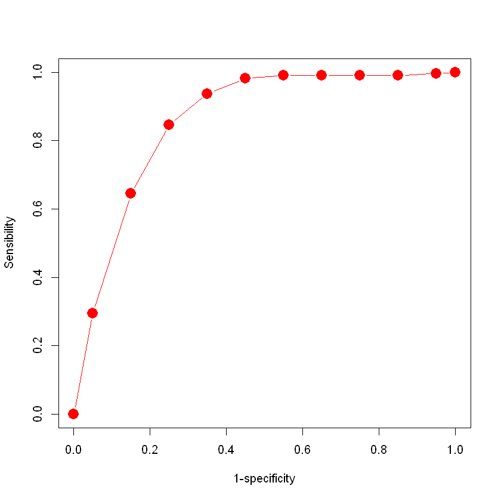

```r
# More details of our model

p3 <- predict(t3, newdata = juice2, type = "class")
# table 5.11
confusion.matrix(p3, juice2[ , "choice"])
#
p3 <-  predict(t3, newdata = juice2, type = "vector")[ , 2]
a <- lift.roc(p3, as.numeric(juice2[ , "choice"] == "MM"), type = "bin", plot.it = FALSE)
# figure 5.21a
plot(a[[1]], a[[2]], type = "b", xlab = "Fraction of predicted subjects",
     ylab = "Improvement factor", col = 2, pch = 16, cex = 2)
# figure 5.21b
plot(a[[3]], a[[4]], type = "b", xlim = c(0, 1), pch = 16,
     ylim = c(0, 1), cex = 2, xlab = "1-specificity",
     ylab = "Sensibility", col = 2)
```

Let's look at one more example before we finish. This code was written and taken from the same [website](http://azzalini.stat.unipd.it) the data has been pulled from.

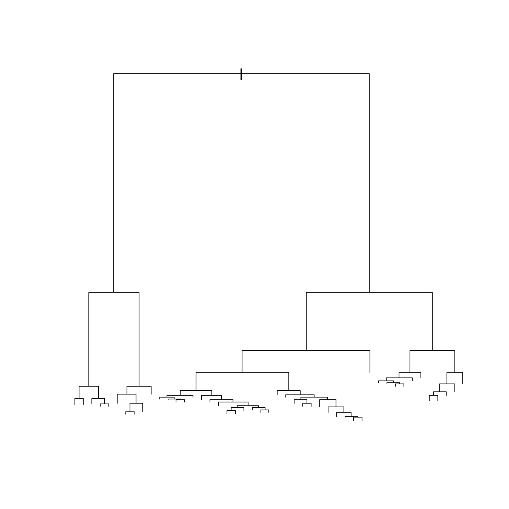

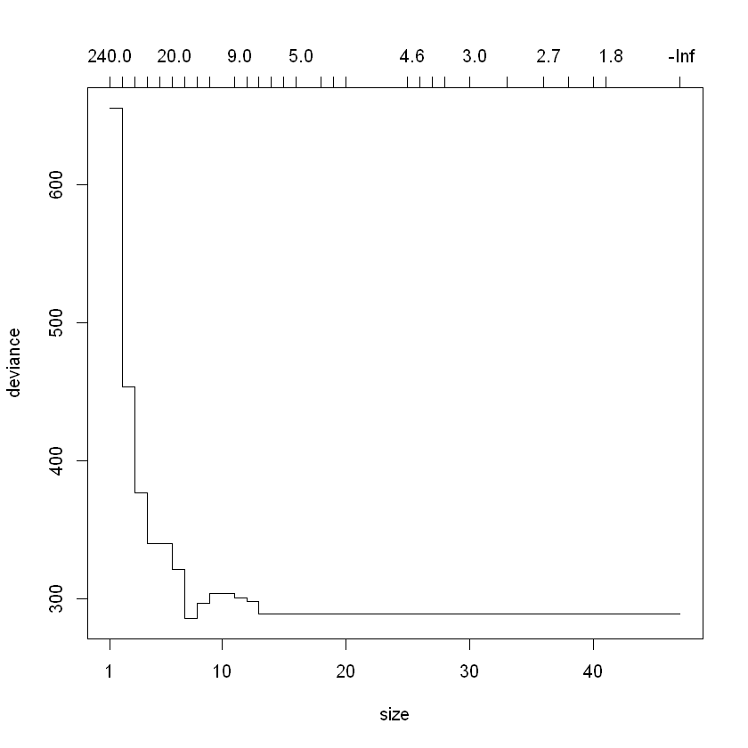

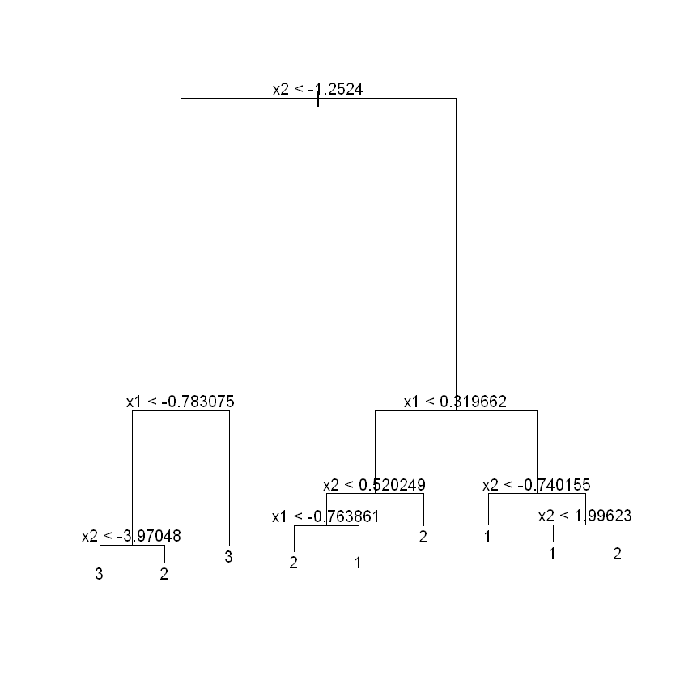

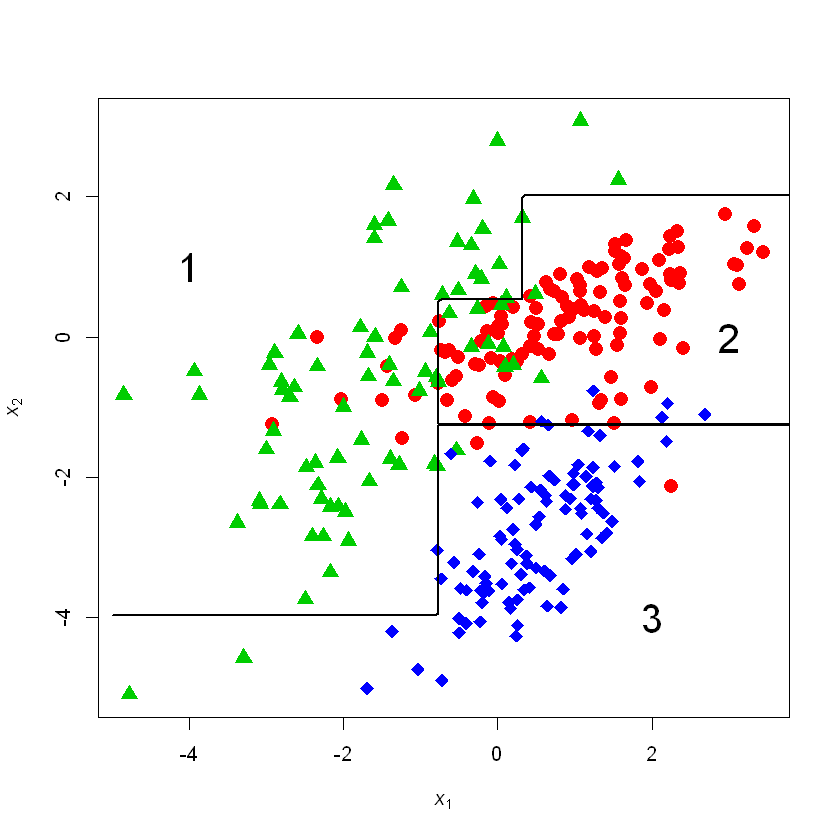

```r
dataset <- read.table("http://azzalini.stat.unipd.it/Book-DM/classes.dat", header = TRUE)
x1 <- dataset[ , 1]
x2 <- dataset[ , 2]
gr <- as.factor(dataset[ , 3])
K <- 3
t3 <- tree(gr ~ x1 + x2, control = tree.control(nobs = nrow(dataset), mindev = 0, minsize = 2))
# figure 5.22a
plot(t3)

set.seed(5)
t4 <- cv.tree(t3)
# figure 5.22b
plot(t4)

t5 <- prune.tree(t3, k = 10)
# figure 5.22c
plot(t5)
text(t5)

n.grid <- 250
p <- pred.square(t5, x1, x2, n.grid)
pred <- array(p$pred, c(n.grid, n.grid,3))
ind <- apply(pred, c(1, 2), order)[3, , ]
# figure 5.22d
plot(dataset[ , 1:2], type = "n", xlab = expression(italic(x)[1]),
     ylab = expression(italic(x)[2]))
for(k in 1:3)
  points(dataset[gr == k, 1:2], pch = 15 + k, col = 1 + k, cex = 1.5)
contour(p$x, p$y, ind, add = TRUE, drawlabels = FALSE, nlevels = 2, lty = 1, lwd = 2)
text(-4, 1, labels = 1, cex = 2)
text(3, 0, labels = 2, cex = 2)
text(2, -4, labels = 3, cex = 2)
```

You may have notice I used some functions that aren't included in any of the libraries we imported. These "helper functions" were developed by A. Azzalini, and are a supplement to his book, *Data Analysis and Data Mining,* which I have used as my guideline for this tutorial.

```r
# help functions
pred.square <- function(model, x1, x2, grid = 50, Z.flag = FALSE)
{
  u <- pretty(x1, n = 10)
  x <- seq(u[1], u[10], length = grid)
  u <- pretty(x2, n = 10)
  y <- seq(u[1], u[10], length = grid)
  nx <- length(x)
  ny <- length(y)
  xoy <- cbind(rep(x, ny), as.vector(matrix(y, nx, ny, byrow = TRUE)))
  X <- matrix(xoy, nx * ny, 2, byrow = FALSE)
  if(Z.flag) pred <- predict(model, newdata = data.frame(z1 = X[ , 1], z2 = X[ , 2]))
  else  pred <- predict(model, newdata = data.frame(x1 = X[ , 1], x2 = X[ , 2]))
  list(pred = pred, x = x, y = y, X = X)
}

# function to procude the ROC curve
lift.roc <- function(previsti, g, type = "bin", plot.it = TRUE)
{
  library(sm)
  if(!is.numeric(g)) stop("g not numeric")
  ind <- rev(order(previsti))
  n <- length(g)
  x1 <- (1:n)/n
  x2 <- cumsum(g[ind]) / (mean(g) * (1:n))
  if(type == "crude" & plot.it)
    plot(x1, x2, type = "l", col = 2,
         xlab = "fraction of predicted subjects", ylab = "lift")
  if(type == "sm") {
    a<- sm.regression(x1, x2, h = 0.1, display = "none")
    if(plot.it)
      plot(a$eval, a$estimate, type = "l", xlim=c(0,1), col = 2,
           xlab = "fraction of predicted subjects", ylab = "lift")
  }
  if(type == "bin") {
    b <-  binning(x1, x2, breaks = (-0.001:10) / 9.999)
    x <- c(0, seq(0.05, 0.95, by = 0.1), 1)
    if (plot.it) plot(x, c(x2[1], b$means, 1), type = "b", xlim = c(0, 1),
                      ylim = c(1, max(x2)), cex = 0.75, col = 2,
                      xlab = "fraction of predicted subjects",
                      ylab = "improvement factor")
    x1 <- x
    x2 <- c(x2[1], b$means,1)
  }
  if(plot.it) pause("press enter")
  u1 <- cumsum(1 - g[ind]) / sum(1 - g)
  u2 <- cumsum(g[ind]) / sum(g)
  if(type == "crude" & plot.it)
    plot(u1, u2, type = "l", xlim = c(0, 1), ylim = c(0, 1), col = 2,
         xlab = "1-specificity", ylab = "sensibility")
  if(type == "sm"){
    # browser()
    eps <- 0.00001
    a <- sm.regression(u1, log((u2 + eps) / (1 - u2 + 2 * eps)), h = 0.1, display = "none")
    q <- exp(a$estimate) / (1 + exp(a$estimate))
    if(plot.it) plot(a$eval, q, type = "l", xlim = c(0, 1), ylim = c(0, 1),
                     xlab = "1-specificity", ylab = "sensibility", col = 2)
  }
  if(type == "bin"){
    b <- binning(u1, u2, breaks = (-0.001:10) / 9.999)
    x <- c(0, seq(0.05, 0.95, by = 0.1),1)
    y<- c(0, b$means,1)
    if(plot.it)
      plot(x, y, type = "b", xlim = c(0,1),
           ylim = c(0, 1),cex = 0.75, xlab = "1-specificity",
           ylab = "sensibility", col = 2)
    u1 <- x
    u2 <- y
  }
  if(plot.it) {
    abline(0, 1, lty = 2, col = 3)
  }
  invisible(list(x1, x2, u1, u2))
}

# function to compute the confusion matrix
confusion.matrix <- function(predicted, observed){
  a <-  table(predicted, observed)
  err.tot <- 1 - sum(diag(a)) / sum(a)
  fn <- a[1, 2] / (a[1, 2] + a[2, 2])
  fp <- a[2, 1] / (a[1, 1] + a[2, 1])
  print(a)
  cat("total error: ", format(err.tot),"\n")
  cat("false positives/negatives: ",format(c(fp, fn)),"\n")
  invisible(a)
}
```